# Data Summarization

## Data Summarization

- Basic statistical summarization
  - `mean(x)`: takes the mean of x
  - `sd(x)`: takes the standard deviation of x
  - `median(x)`: takes the median of x
  - `quantile(x)`: displays sample quantiles of x. Default is min, IQR, max
  - `range(x)`: displays the range. Same as `c(min(x), max(x))`
  - `sum(x)`: sum of x
  - `max(x)`: maximum value in x
  - `min(x)`: minimum value in x
- **all have the** `na.rm =` **argument for missing data**

## Statistical summarization

These functions work on **vectors**:

```r
x <- c(1, 5, 7, 4, 2, 8)
mean(x)
```

```
[1] 4.5
```

Summarization on a `data.frame`/`tibble`:

```r
mtcars |> pull(hp) |> mean()
```

```
[1] 146.6875
```

## GUT CHECK!

What kind of object do we need to run summary operators like `mean()` ?

A. A vector of numbers

B. A vector of characters

C. A dataset

## UFO Data

Let’s use the UFO data again:

```r
ufo <- read_csv("https://sisbid.github.io/Data-Wrangling/data/ufo/ufo_data_complete.csv")
ufo <- ufo |> rename(duration_s = `duration (seconds)`)
head(ufo)
```

```
# A tibble: 6 × 11
  datetime  city  state country shape duration_s `duration (hours/min)` comments
  <chr>     <chr> <chr> <chr>   <chr>      <dbl> <chr>                  <chr>
1 10/10/19… san … tx    us      cyli…       2700 45 minutes             This ev…
2 10/10/19… lack… tx    <NA>    light       7200 1-2 hrs                1949 La…
3 10/10/19… ches… <NA>  gb      circ…         20 20 seconds             Green/O…
4 10/10/19… edna  tx    us      circ…         20 1/2 hour               My olde…
5 10/10/19… kane… hi    us      light        900 15 minutes             AS a Ma…
6 10/10/19… bris… tn    us      sphe…        300 5 minutes              My fath…
# ℹ 3 more variables: `date posted` <chr>, latitude <chr>, longitude <chr>
```

## Column to vector

Summarize a column as a vector with `pull()`.

```r
ufo |> pull(duration_s) |> mean()
```

```
[1] NA
```

```r
ufo |> pull(duration_s) |> mean(na.rm=TRUE)
```

```
[1] 8373.412
```

```r
ufo |> pull(duration_s) |> median(na.rm=TRUE)
```

```
[1] 120
```

## `dplyr`: `count`

`count`: the number of rows in each group.

```r
ufo |> count(country)
```

```
# A tibble: 6 × 2
  country     n
  <chr>   <int>
1 au        593
2 ca       3266
3 de        112
4 gb       2050
5 us      70293
6 <NA>    12561
```

## `dplyr`: `count`

Multiple columns listed further subdivides the count.

```r
ufo |> count(country, shape)
```

```
# A tibble: 139 × 3
   country shape        n
   <chr>   <chr>    <int>
 1 au      changing    10
 2 au      chevron      3
 3 au      cigar       18
 4 au      circle      68
 5 au      cone         8
 6 au      cross        3
 7 au      cylinder    10
 8 au      diamond     11
 9 au      disk        62
10 au      egg         12
# ℹ 129 more rows
```

## `dplyr`: `count`

Option to sort the results with `sort = TRUE`

```r
ufo |> count(country, sort = TRUE)
```

```
# A tibble: 6 × 2
  country     n
  <chr>   <int>
1 us      70293
2 <NA>    12561
3 ca       3266
4 gb       2050
5 au        593
6 de        112
```

## GUT CHECK!

The `count()` function can help us tally:

A. Sample size

B. Rows per each category

C. How many categories

## `dplyr`: `count`

Instead of counting the **number of rows** in each group, `wt` computes sum() of a column for each group.

```r
# Add up "duration_s" for each "country" category
ufo |> count(country, wt = duration_s)
```

```
# A tibble: 6 × 2
  country          n
  <chr>        <dbl>
1 au        2047880.
2 ca       86578311.
3 de        2546878
4 gb      125846817.
5 us      377662105.
6 <NA>    149463090.
```

## Grouping

## Perform Operations By Groups: dplyr

Regular data…

```r
# No group_by()
ufo
```

```
# A tibble: 88,875 × 11
   datetime city  state country shape duration_s `duration (hours/min)` comments
   <chr>    <chr> <chr> <chr>   <chr>      <dbl> <chr>                  <chr>
 1 10/10/1… san … tx    us      cyli…       2700 45 minutes             This ev…
 2 10/10/1… lack… tx    <NA>    light       7200 1-2 hrs                1949 La…
 3 10/10/1… ches… <NA>  gb      circ…         20 20 seconds             Green/O…
 4 10/10/1… edna  tx    us      circ…         20 1/2 hour               My olde…
 5 10/10/1… kane… hi    us      light        900 15 minutes             AS a Ma…
 6 10/10/1… bris… tn    us      sphe…        300 5 minutes              My fath…
 7 10/10/1… pena… <NA>  gb      circ…        180 about 3 mins           penarth…
 8 10/10/1… norw… ct    us      disk        1200 20 minutes             A brigh…
 9 10/10/1… pell… al    us      disk         180 3  minutes             Strobe …
10 10/10/1… live… fl    us      disk         120 several minutes        Saucer …
# ℹ 88,865 more rows
# ℹ 3 more variables: `date posted` <chr>, latitude <chr>, longitude <chr>
```

## Perform Operations By Groups: dplyr

`group_by` allows you group the data set by variables/columns you specify:

```r
ufo_grouped <- ufo |> group_by(country)
ufo_grouped
```

```
# A tibble: 88,875 × 11
# Groups:   country [6]
   datetime city  state country shape duration_s `duration (hours/min)` comments
   <chr>    <chr> <chr> <chr>   <chr>      <dbl> <chr>                  <chr>
 1 10/10/1… san … tx    us      cyli…       2700 45 minutes             This ev…
 2 10/10/1… lack… tx    <NA>    light       7200 1-2 hrs                1949 La…
 3 10/10/1… ches… <NA>  gb      circ…         20 20 seconds             Green/O…
 4 10/10/1… edna  tx    us      circ…         20 1/2 hour               My olde…
 5 10/10/1… kane… hi    us      light        900 15 minutes             AS a Ma…
 6 10/10/1… bris… tn    us      sphe…        300 5 minutes              My fath…
 7 10/10/1… pena… <NA>  gb      circ…        180 about 3 mins           penarth…
 8 10/10/1… norw… ct    us      disk        1200 20 minutes             A brigh…
 9 10/10/1… pell… al    us      disk         180 3  minutes             Strobe …
10 10/10/1… live… fl    us      disk         120 several minutes        Saucer …
# ℹ 88,865 more rows
# ℹ 3 more variables: `date posted` <chr>, latitude <chr>, longitude <chr>
```

## Summarize the grouped data

We can summarize grouped data using `summarize()`:

```r
ufo_grouped |>
  summarize(mean_value = mean(duration_s, na.rm = TRUE))
```

```
# A tibble: 6 × 2
  country mean_value
  <chr>        <dbl>
1 au           3453.
2 ca          26509.
3 de          22740.
4 gb          61389.
5 us           5373.
6 <NA>        11901.
```

## Visual of `summarize`

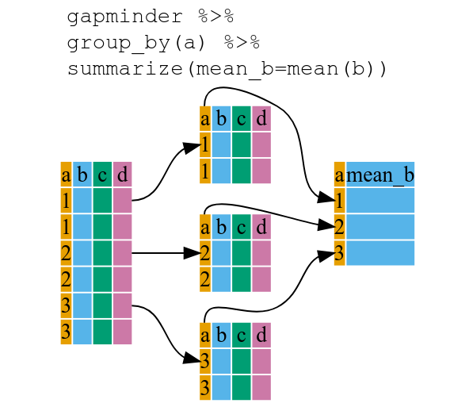

[source](https://swcarpentry.github.io/r-novice-gapminder/instructor/images.html)

## Use the `pipe` to string these together!

Pipe `ufo` into `group_by`, then pipe that into `summarize`:

```r
ufo |>
  group_by(country) |>
  summarize(mean_value = mean(duration_s, na.rm = TRUE),
            max_value = max(duration_s, na.rm = TRUE))
```

```
# A tibble: 6 × 3
  country mean_value max_value
  <chr>        <dbl>     <dbl>
1 au           3453.   1209600
2 ca          26509.  82800000
3 de          22740.   1814400
4 gb          61389.  97836000
5 us           5373.  66276000
6 <NA>        11901.  52623200
```

## `group_by` with `mutate` - Useful for comparisons

Use `group_by` to calculate the mean value for each country. We can use `mutate` to add it as a column.

```r
ufo_compare <- ufo |>
  group_by(country) |>
  mutate(duration_country_avg = mean(duration_s, na.rm = TRUE)) |>
  select(country, duration_s, duration_country_avg)
ufo_compare
```

```
# A tibble: 88,875 × 3
# Groups:   country [6]
   country duration_s duration_country_avg
   <chr>        <dbl>                <dbl>
 1 us            2700                5373.
 2 <NA>          7200               11901.
 3 gb              20               61389.
 4 us              20                5373.
 5 us             900                5373.
 6 us             300                5373.
 7 gb             180               61389.
 8 us            1200                5373.
 9 us             180                5373.
10 us             120                5373.
# ℹ 88,865 more rows
```

## `group_by` with `mutate` - Useful for comparisons

Create a “difference” variable:

```r
ufo_compare |> mutate(diff = duration_s - duration_country_avg)
```

```
# A tibble: 88,875 × 4
# Groups:   country [6]
   country duration_s duration_country_avg    diff
   <chr>        <dbl>                <dbl>   <dbl>
 1 us            2700                5373.  -2673.
 2 <NA>          7200               11901.  -4701.
 3 gb              20               61389. -61369.
 4 us              20                5373.  -5353.
 5 us             900                5373.  -4473.
 6 us             300                5373.  -5073.
 7 gb             180               61389. -61209.
 8 us            1200                5373.  -4173.
 9 us             180                5373.  -5193.
10 us             120                5373.  -5253.
# ℹ 88,865 more rows
```

## Iterative summaries

## Iterative summaries: `dplyr` `summarize()` and `across()` functions

Use the [`across`](https://dplyr.tidyverse.org/reference/across.html) function with `summarize()` to summarize across multiple columns of your data.

```r
dropouts <- read_delim("https://sisbid.github.io/Data-Wrangling/data/dropouts.txt", delim = "/")
dropouts |>
  group_by(ETHNIC) |>
  summarize(across(c(D9, D10, D11, D12), ~sum(.x)))
```

```
# A tibble: 9 × 5
  ETHNIC    D9   D10   D11   D12
   <dbl> <dbl> <dbl> <dbl> <dbl>
1      0  1226   299   308   478
2      1   103    82   124   265
3      2   118   114   132   767
4      3    37    25    34   135
5      4    34    30    51   252
6      5  4433  3543  4723 16220
7      6   817   617   875  2890
8      7   768   878  1432  3998
9      9   162   155   194   636
```

## Select different columns based on the data class

Use `?tidyr_tidy_select` functions like `where(is.numeric)`!

```r
dropouts |>
  group_by(ETHNIC) |>
  summarize(across( where(is.numeric), ~ sum(.x, na.rm = TRUE)))
```

```
# A tibble: 9 × 18
  ETHNIC     E7     E8     E9    E10    E11    E12   EUS    ETOT    D7    D8
   <dbl>  <dbl>  <dbl>  <dbl>  <dbl>  <dbl>  <dbl> <dbl>   <dbl> <dbl> <dbl>
1      0   2922   2709   3140   3291   2776   2345    43   11595    66    52
2      1   2523   2589   2808   2886   2889   3020    33   11636    16    15
3      2  44199  43898  43343  43757  45840  43001   596  176537    69    37
4      3   2390   2284   2436   2352   2471   2571    42    9872     9     7
5      4  12210  12883  13429  14037  14273  14469   233   56441    12     8
6      5 254745 252583 264302 260201 252458 253193  2680 1032834   682   550
7      6  26383  26786  28497  28731  28696  30799   485  117208   217   164
8      7 113498 115139 115593 117592 119308 121771  1829  476093   323   267
9      9  14704  13469  13999  13238  12810  13000   138   53185    59    38
# ℹ 7 more variables: D9 <dbl>, D10 <dbl>, D11 <dbl>, D12 <dbl>, DUS <dbl>,
#   DTOT <dbl>, YEAR <dbl>
```

## `summary()` Function

```r
summary(dropouts)
```

```
      CDS_CODE         ETHNIC            GENDER            E7
 Length   :59599   Min.   :0.000   Length   :59599   Min.   :  0.000
 N.unique : 5507   1st Qu.:2.000   N.unique :    2   1st Qu.:  0.000
 N.blank  :    0   Median :5.000   N.blank  :    0   Median :  0.000
 Min.nchar:   14   Mean   :4.737   Min.nchar:    1   Mean   :  7.946
 Max.nchar:   14   3rd Qu.:7.000   Max.nchar:    1   3rd Qu.:  3.000
                   Max.   :9.000                     Max.   :373.000
       E8                E9              E10               E11
 Min.   :  0.000   Min.   :  0.00   Min.   :  0.000   Min.   :  0.000
 1st Qu.:  0.000   1st Qu.:  0.00   1st Qu.:  0.000   1st Qu.:  0.000
 Median :  0.000   Median :  0.00   Median :  0.000   Median :  0.000
 Mean   :  7.925   Mean   :  8.18   Mean   :  8.156   Mean   :  8.079
 3rd Qu.:  3.000   3rd Qu.:  2.00   3rd Qu.:  2.000   3rd Qu.:  2.000
 Max.   :363.000   Max.   :567.00   Max.   :537.000   Max.   :620.000
      E12               EUS              ETOT               D7
 Min.   :  0.000   Min.   : 0.000   Min.   :   0.00   Min.   : 0.00000
 1st Qu.:  0.000   1st Qu.: 0.000   1st Qu.:   0.00   1st Qu.: 0.00000
 Median :  0.000   Median : 0.000   Median :   1.00   Median : 0.00000
 Mean   :  8.124   Mean   : 0.102   Mean   :  32.64   Mean   : 0.02438
 3rd Qu.:  2.000   3rd Qu.: 0.000   3rd Qu.:   9.00   3rd Qu.: 0.00000
 Max.   :490.000   Max.   :77.000   Max.   :2127.00   Max.   :15.00000
       D8                D9                D10                D11
 Min.   :0.00000   Min.   :  0.0000   Min.   : 0.00000   Min.   :  0.0000
 1st Qu.:0.00000   1st Qu.:  0.0000   1st Qu.: 0.00000   1st Qu.:  0.0000
 Median :0.00000   Median :  0.0000   Median : 0.00000   Median :  0.0000
 Mean   :0.01909   Mean   :  0.1292   Mean   : 0.09636   Mean   :  0.1321
 3rd Qu.:0.00000   3rd Qu.:  0.0000   3rd Qu.: 0.00000   3rd Qu.:  0.0000
 Max.   :8.00000   Max.   :461.0000   Max.   :80.00000   Max.   :108.0000
      D12                DUS                 DTOT               YEAR
 Min.   :  0.0000   Min.   : 0.000000   Min.   :  0.0000   Min.   :1617
 1st Qu.:  0.0000   1st Qu.: 0.000000   1st Qu.:  0.0000   1st Qu.:1617
 Median :  0.0000   Median : 0.000000   Median :  0.0000   Median :1617
 Mean   :  0.4302   Mean   : 0.004933   Mean   :  0.7928   Mean   :1617
 3rd Qu.:  0.0000   3rd Qu.: 0.000000   3rd Qu.:  0.0000   3rd Qu.:1617
 Max.   :372.0000   Max.   :11.000000   Max.   :541.0000   Max.   :1617
```

## Summary

- summary stats (`mean()`) work with `pull()`
- `count(x)`: what unique values do you have?
- `group_by()`: changes all subsequent functions
  - combine with `summarize()` to get statistics per group
  - combine with `across()` to select several columns
- `summary(x)`: quantile information

https://sisbid.github.io/Data-Wrangling/08_Data_Summarization/lab/data-summarization-lab.Rmd